# Project_Ensemble_Techniques_MAILLON_Remi

## Background and Context

You are a Data Scientist for a tourism company named "Visit with us". The Policy Maker of the company wants to enable and establish a viable business model to expand the customer base.

A viable business model is a central concept that helps you to understand the existing ways of doing the business and how to change the ways for the benefit of the tourism sector.

One of the ways to expand the customer base is to introduce a new offering of packages.

Currently, there are 5 types of packages the company is offering - Basic, Standard, Deluxe, Super Deluxe, King. Looking at the data of the last year, we observed that 18% of the customers purchased the packages.

However, the marketing cost was quite high because customers were contacted at random without looking at the available information.

The company is now planning to launch a new product i.e. Wellness Tourism Package. Wellness Tourism is defined as Travel that allows the traveler to maintain, enhance or kick-start a healthy lifestyle, and support or increase one's sense of well-being.

However, this time company wants to harness the available data of existing and potential customers to make the marketing expenditure more efficient.

You as a Data Scientist at "Visit with us" travel company have to analyze the customers' data and information to provide recommendations to the Policy Maker and Marketing Team and also build a model to predict the potential customer who is going to purchase the newly introduced package.

## Objective

To predict which customer is more likely to purchase the newly introduced travel package.

## Data Dictionary

### Customer details:

1. CustomerID: Unique customer ID
2. ProdTaken: Product taken flag
3. Age: Age of customer
4. PreferredLoginDevice: Preferred login device of the customer in last month
5. CityTier: City tier
6. Occupation: Occupation of customer
7. Gender: Gender of customer
8. NumberOfPersonVisited: Total number of person came with customer
9. PreferredPropertyStar: Preferred hotel property rating by customer
10. MaritalStatus: Marital status of customer
11. NumberOfTrips: Average number of the trip in a year by customer
12. Passport: Customer passport flag
13. OwnCar: Customers owns a car flag
14. NumberOfChildrenVisited: Total number of children visit with customer
15. Designation: Designation of the customer in the current organization
16. MonthlyIncome: Gross monthly income of the customer

### Customer interaction data:

1. PitchSatisfactionScore: Sales pitch satisfactory score
2. ProductPitched: Product pitched by a salesperson
3. NumberOfFollowups: Total number of follow up has been done by sales person after sales pitch
4. DurationOfPitch: Duration of the pitch by a salesman to customer

## Perform an Exploratory Data Analysis on the data

Univariate analysis - Bivariate analysis - Use appropriate visualizations to identify the patterns and insights - Come up with a customer profile (characteristics of a customer) of the different packages - Any other exploratory deep dive

### Import libraries

```python
import pandas as pd
import numpy as np
import matplotlib.pyplot as plt
import seaborn as sns
from sklearn import metrics
from sklearn.model_selection import train_test_split, GridSearchCV
from sklearn import tree
from sklearn.linear_model import LogisticRegression
from sklearn.ensemble import RandomForestClassifier, AdaBoostClassifier, GradientBoostingClassifier, BaggingClassifier, StackingClassifier
from xgboost import XGBClassifier
```

### Read the dataset

```python
data = pd.read_excel('Tourism.xlsx', sheet_name='Tourism')
```

```python
data
```

|  | CustomerID | ProdTaken | Age | PreferredLoginDevice | CityTier | DurationOfPitch | Occupation | Gender | NumberOfPersonVisited | NumberOfFollowups | ProductPitched | PreferredPropertyStar | MaritalStatus | NumberOfTrips | Passport | PitchSatisfactionScore | OwnCar | NumberOfChildrenVisited | Designation | MonthlyIncome |
| --- | --- | --- | --- | --- | --- | --- | --- | --- | --- | --- | --- | --- | --- | --- | --- | --- | --- | --- | --- | --- |
| 0 | 200000 | 1 | 41.0 | Self Enquiry | 3 | 6.0 | Salaried | Female | 3 | 3.0 | Super Deluxe | 3.0 | Single | 1.0 | 1 | 2 | 1 | 0.0 | Manager | 20993.0 |
| 1 | 200001 | 0 | 49.0 | Company Invited | 1 | 14.0 | Salaried | Male | 3 | 4.0 | Super Deluxe | 4.0 | Divorced | 2.0 | 0 | 3 | 1 | 2.0 | Manager | 20130.0 |
| 2 | 200002 | 1 | 37.0 | Self Enquiry | 1 | 8.0 | Free Lancer | Male | 3 | 4.0 | Multi | 3.0 | Single | 7.0 | 1 | 3 | 0 | 0.0 | Executive | 17090.0 |
| 3 | 200003 | 0 | 33.0 | Company Invited | 1 | 9.0 | Salaried | Female | 2 | 3.0 | Multi | 3.0 | Divorced | 2.0 | 1 | 5 | 1 | 1.0 | Executive | 17909.0 |
| 4 | 200004 | 0 | NaN | Self Enquiry | 1 | 8.0 | Small Business | Male | 2 | 3.0 | Multi | 4.0 | Divorced | 1.0 | 0 | 5 | 1 | 0.0 | Executive | 18468.0 |
| ... | ... | ... | ... | ... | ... | ... | ... | ... | ... | ... | ... | ... | ... | ... | ... | ... | ... | ... | ... | ... |
| 4883 | 204883 | 1 | 49.0 | Self Enquiry | 3 | 9.0 | Small Business | Male | 3 | 5.0 | Super Deluxe | 4.0 | Unmarried | 2.0 | 1 | 1 | 1 | 1.0 | Manager | 26576.0 |
| 4884 | 204884 | 1 | 28.0 | Company Invited | 1 | 31.0 | Salaried | Male | 4 | 5.0 | Multi | 3.0 | Single | 3.0 | 1 | 3 | 1 | 2.0 | Executive | 21212.0 |
| 4885 | 204885 | 1 | 52.0 | Self Enquiry | 3 | 17.0 | Salaried | Female | 4 | 4.0 | Standard | 4.0 | Married | 7.0 | 0 | 1 | 1 | 3.0 | Senior Manager | 31820.0 |
| 4886 | 204886 | 1 | 19.0 | Self Enquiry | 3 | 16.0 | Small Business | Male | 3 | 4.0 | Multi | 3.0 | Single | 3.0 | 0 | 5 | 0 | 2.0 | Executive | 20289.0 |
| 4887 | 204887 | 1 | 36.0 | Self Enquiry | 1 | 14.0 | Salaried | Male | 4 | 4.0 | Multi | 4.0 | Unmarried | 3.0 | 1 | 3 | 1 | 2.0 | Executive | 24041.0 |

4888 rows × 20 columns

```python
data.shape
```

```
(4888, 20)
```

```python
data.info()
```

```
<class 'pandas.core.frame.DataFrame'>
RangeIndex: 4888 entries, 0 to 4887
Data columns (total 20 columns):
 #   Column                   Non-Null Count  Dtype
---  ------                   --------------  -----
 0   CustomerID               4888 non-null   int64
 1   ProdTaken                4888 non-null   int64
 2   Age                      4662 non-null   float64
 3   PreferredLoginDevice     4863 non-null   object
 4   CityTier                 4888 non-null   int64
 5   DurationOfPitch          4637 non-null   float64
 6   Occupation               4888 non-null   object
 7   Gender                   4888 non-null   object
 8   NumberOfPersonVisited    4888 non-null   int64
 9   NumberOfFollowups        4843 non-null   float64
 10  ProductPitched           4888 non-null   object
 11  PreferredPropertyStar    4862 non-null   float64
 12  MaritalStatus            4888 non-null   object
 13  NumberOfTrips            4748 non-null   float64
 14  Passport                 4888 non-null   int64
 15  PitchSatisfactionScore   4888 non-null   int64
 16  OwnCar                   4888 non-null   int64
 17  NumberOfChildrenVisited  4822 non-null   float64
 18  Designation              4888 non-null   object
 19  MonthlyIncome            4655 non-null   float64
dtypes: float64(7), int64(7), object(6)
memory usage: 763.9+ KB
```

- We can drop 'CustomerID' column as it is an ID variable and will not add value to the model.

```python
data.drop('CustomerID', axis=1, inplace=True)
```

```python
data.describe().T
```

|  | count | mean | std | min | 25% | 50% | 75% | max |
| --- | --- | --- | --- | --- | --- | --- | --- | --- |
| ProdTaken | 4888.0 | 0.188216 | 0.390925 | 0.0 | 0.0 | 0.0 | 0.0 | 1.0 |
| Age | 4662.0 | 37.622265 | 9.316387 | 18.0 | 31.0 | 36.0 | 44.0 | 61.0 |
| CityTier | 4888.0 | 1.654255 | 0.916583 | 1.0 | 1.0 | 1.0 | 3.0 | 3.0 |
| DurationOfPitch | 4637.0 | 15.490835 | 8.519643 | 5.0 | 9.0 | 13.0 | 20.0 | 127.0 |
| NumberOfPersonVisited | 4888.0 | 2.905074 | 0.724891 | 1.0 | 2.0 | 3.0 | 3.0 | 5.0 |
| NumberOfFollowups | 4843.0 | 3.708445 | 1.002509 | 1.0 | 3.0 | 4.0 | 4.0 | 6.0 |
| PreferredPropertyStar | 4862.0 | 3.581037 | 0.798009 | 3.0 | 3.0 | 3.0 | 4.0 | 5.0 |
| NumberOfTrips | 4748.0 | 3.236521 | 1.849019 | 1.0 | 2.0 | 3.0 | 4.0 | 22.0 |
| Passport | 4888.0 | 0.290917 | 0.454232 | 0.0 | 0.0 | 0.0 | 1.0 | 1.0 |
| PitchSatisfactionScore | 4888.0 | 3.078151 | 1.365792 | 1.0 | 2.0 | 3.0 | 4.0 | 5.0 |
| OwnCar | 4888.0 | 0.620295 | 0.485363 | 0.0 | 0.0 | 1.0 | 1.0 | 1.0 |
| NumberOfChildrenVisited | 4822.0 | 1.187267 | 0.857861 | 0.0 | 1.0 | 1.0 | 2.0 | 3.0 |
| MonthlyIncome | 4655.0 | 23619.853491 | 5380.698361 | 1000.0 | 20346.0 | 22347.0 | 25571.0 | 98678.0 |

### Univariate analysis

```python
# While doing uni-variate analysis of numerical variables we want to study their central tendency
# and dispersion.
# Let us write a function that will help us create boxplot and histogram for any input numerical
# variable.
# This function takes the numerical column as the input and returns the boxplots
# and histograms for the variable.
# Let us see if this help us write faster and cleaner code.
def histogram_boxplot(feature, figsize=(15,7), bins = None):
    """ Boxplot and histogram combined
    feature: 1-d feature array
    figsize: size of fig (default (9,8))
    bins: number of bins (default None / auto)
    """
    f2, (ax_box2, ax_hist2) = plt.subplots(nrows = 2, # Number of rows of the subplot grid= 2
                                           sharex = True, # x-axis will be shared among all subplots
                                           gridspec_kw = {"height_ratios": (.25, .75)},
                                           figsize = figsize
                                           ) # creating the 2 subplots
    sns.boxplot(x=feature, data=data, ax=ax_box2, showmeans=True, color='violet') # boxplot will be created and a star will indicate the mean value of the column
    sns.histplot(x=feature, data=data, kde=False, ax=ax_hist2, bins=bins,palette="winter") if bins else sns.histplot(x=feature, data=data, kde=False, ax=ax_hist2) # For histogram
    ax_hist2.axvline(data[feature].mean(), color='green', linestyle='--') # Add mean to the histogram
    ax_hist2.axvline(data[feature].median(), color='black', linestyle='-') # Add median to the histogram
```

#### Age of customers

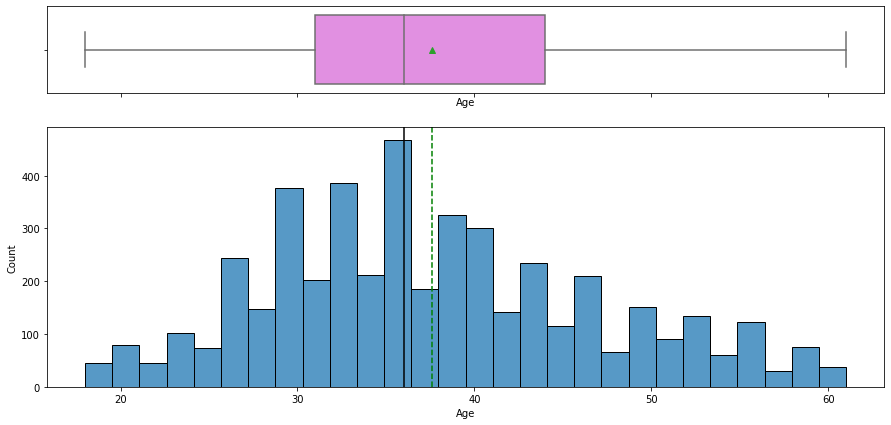

```python
histogram_boxplot('Age')
```

- The distribution of age is slightly right-skewed.
- Age of customers is ranging from 18 to 61 with an average of 37.6 and a median of 36 years old.
- There are no outliers in this variable.

#### Duration of pitch

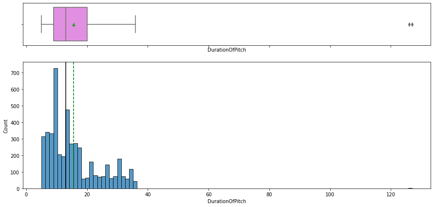

```python
histogram_boxplot('DurationOfPitch')
```

- The distribution of duration of pitch is right-skewed
- The two outliers (126 and 127 minutes) could be the result of a typo.
- Average duration of the pitch is 15.5 minutes with a median of 13 minutes.
- Most pitches are ranging between 5 and 36 minutes.

#### Number of trips per year

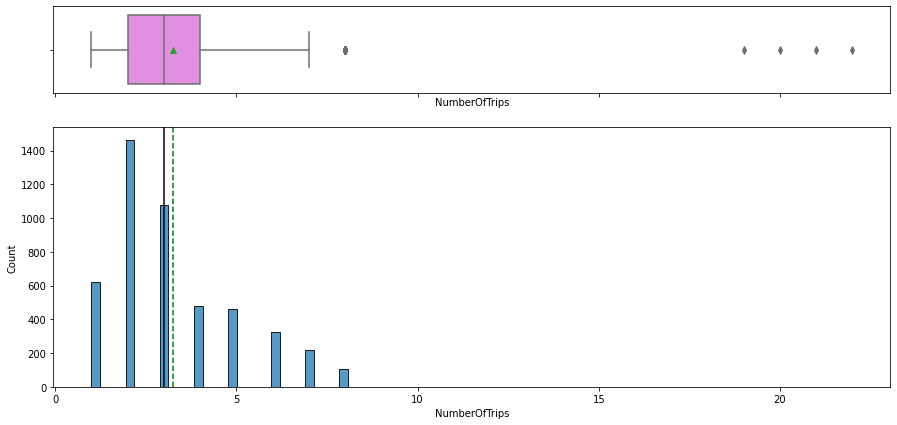

```python
histogram_boxplot('NumberOfTrips')
```

#### Monthly income

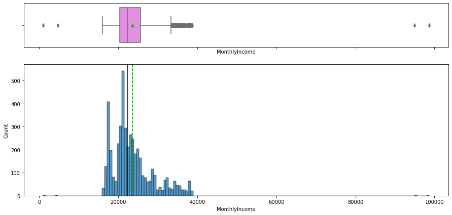

```python
histogram_boxplot('MonthlyIncome')
```

- The distribution of monthly income is right-skewed.
- Most customers have monthly income ranging between 16,009 and 38,677 with an average of 23,620 and a median of 22,347.
- There could to be four outliers in the data: 1,000 - 4,678 - 95,000 - 98,678 seem out of range.

#### Product taken

```python
def perc_on_bar(feature, figsize=(10,5), palette='Blues'):
    '''
    plot
    feature: categorical feature
    the function won't work if a column is passed in hue parameter
    '''
    total = len(data[feature]) # length of the column
    plt.figure(figsize=figsize)
    ax = sns.countplot(x=feature, data=data, palette=palette)
    for p in ax.patches:
        percentage = '{:.1f}%'.format(100 * p.get_height()/total) # percentage of each class of the category
        x = p.get_x() + p.get_width() / 2 - .05 # width of the plot
        y = p.get_height() + 30         # hieght of the plot
        ax.annotate(percentage, (x, y), size = 12) # annotate the percantage
    plt.show()
```

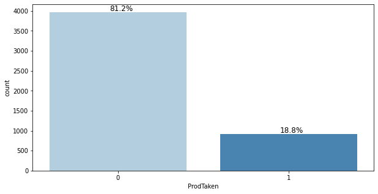

```python
perc_on_bar('ProdTaken')
```

- This is our target variable
- Most customers do not take the product with only 18.8 % of customers buying the product.

#### Preferred login device

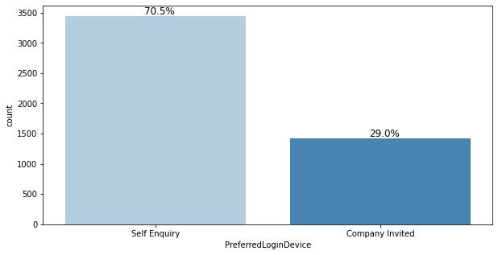

```python
perc_on_bar('PreferredLoginDevice')
```

- Most customers are from self enquiry rather than company invited

#### City tier

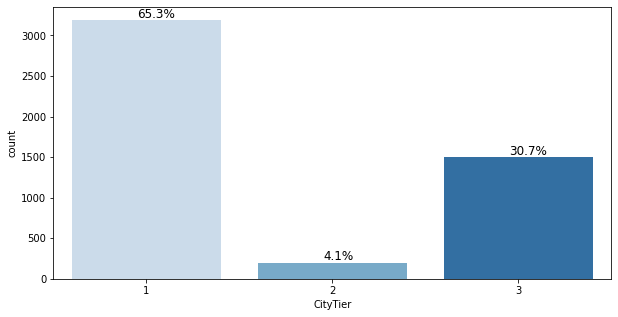

```python
perc_on_bar('CityTier')
```

- Most customers are from city tier 1

#### Occupation

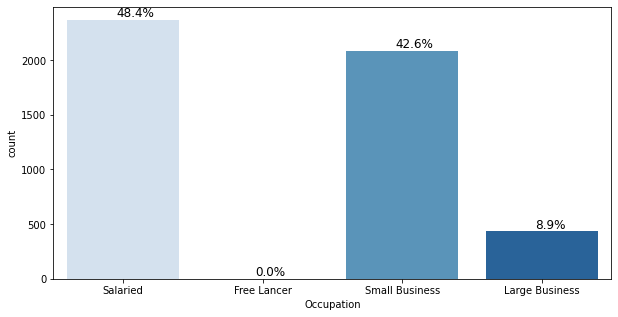

```python
perc_on_bar('Occupation')
```

- Most customers are salaried or from small businesses.
- There arer only few customers being free lancers with less than 0.1%

#### Gender

```python
data['Gender'].replace('Fe Male', 'Female', inplace=True)
```

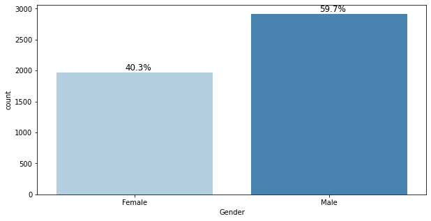

```python
perc_on_bar('Gender')
```

- There are more male customers than female customers.

#### Number of person visited

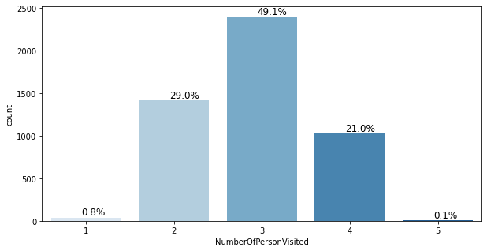

```python
perc_on_bar('NumberOfPersonVisited')
```

- Most customers come in group of 3 persons

#### Number of follow ups

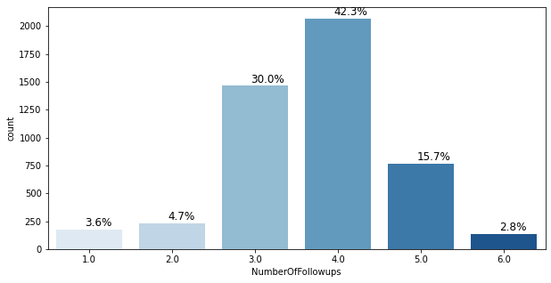

```python
perc_on_bar('NumberOfFollowups')
```

- Number of follow ups ranges between 1 to 6 with mostly 3 or 4 follow ups.

#### Product pitched

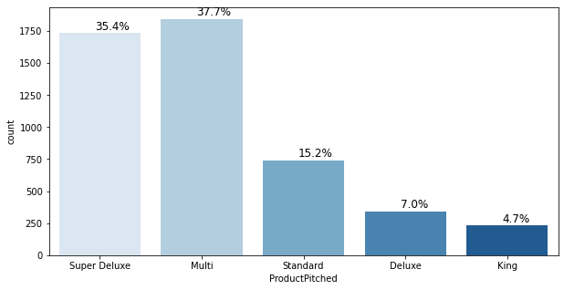

```python
perc_on_bar('ProductPitched')
```

- Most often the product pitched is either Super Deluxe or Multi

#### Preferred hotel property rating by customer

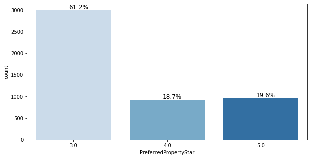

```python
perc_on_bar('PreferredPropertyStar')
```

- Customers are only staying in 3 or more stars hotels with most of them staying in 3 stars hotels.

#### Marital status

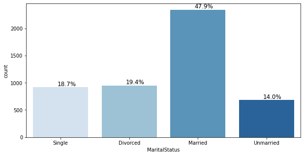

```python
perc_on_bar('MaritalStatus')
```

- Most customers are married

#### Passport

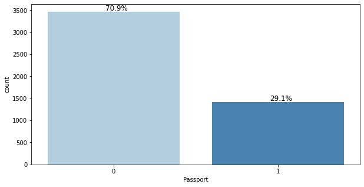

```python
perc_on_bar('Passport')
```

- Most customers do not have a passport

#### Pitch satisfaction score

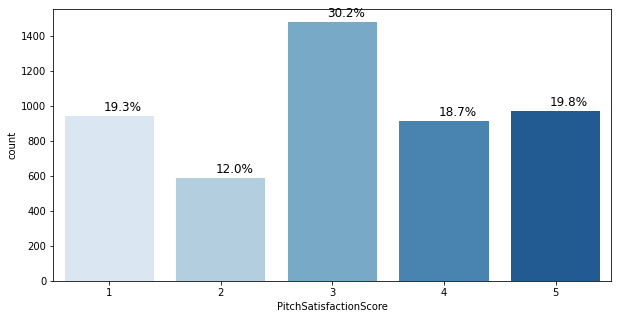

```python
perc_on_bar('PitchSatisfactionScore')
```

- Sales pitch satisfactory score ranges from 1 to 5 with more than 30% of scores being 3.

#### Own car

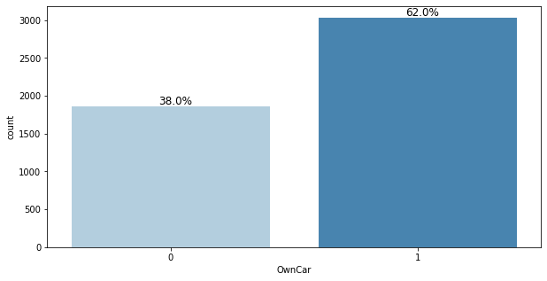

```python
perc_on_bar('OwnCar')
```

- 62 % of customers have their own car

#### Number of children visited

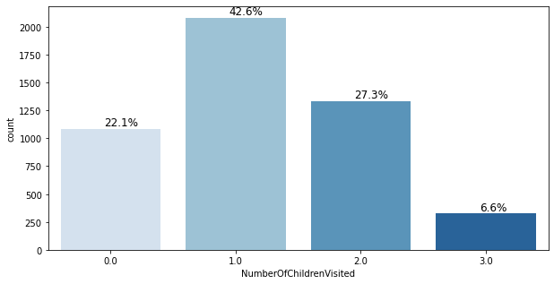

```python
perc_on_bar('NumberOfChildrenVisited')
```

- Number of children visit with customer ranges between 0 and 3 with 42.6 % of visits having only one child.

#### Designation

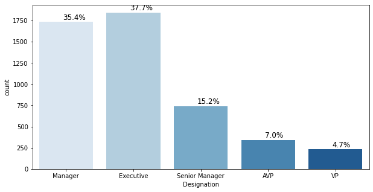

```python
perc_on_bar('Designation')
```

- More than two thirds of customers are either managers or executives

### Bivariate analysis

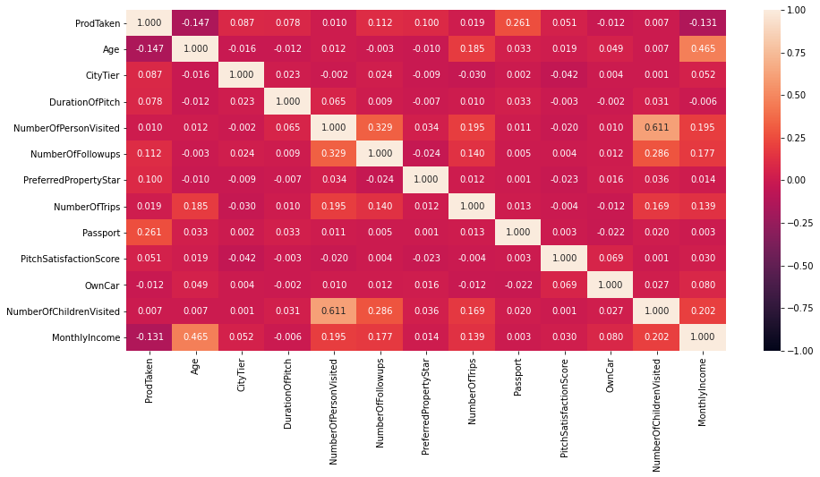

```python
plt.figure(figsize=(15,7))
sns.heatmap(data.corr(),annot=True, fmt='.3f', vmin=-1);
```

- The number of person visited is highly correlated to the number of children visited (Pearson's coefficient: 0.611). Therefore, we could consider using only one of the two variables in the model.
- The monthly income is highly correlated to the age which makes perfect sense given the longer experience.
- Customers who have a passport are more likely to take the product. Indeed a passport is normally required in order to travel abroad.
- Younger customers are more likely to take the product

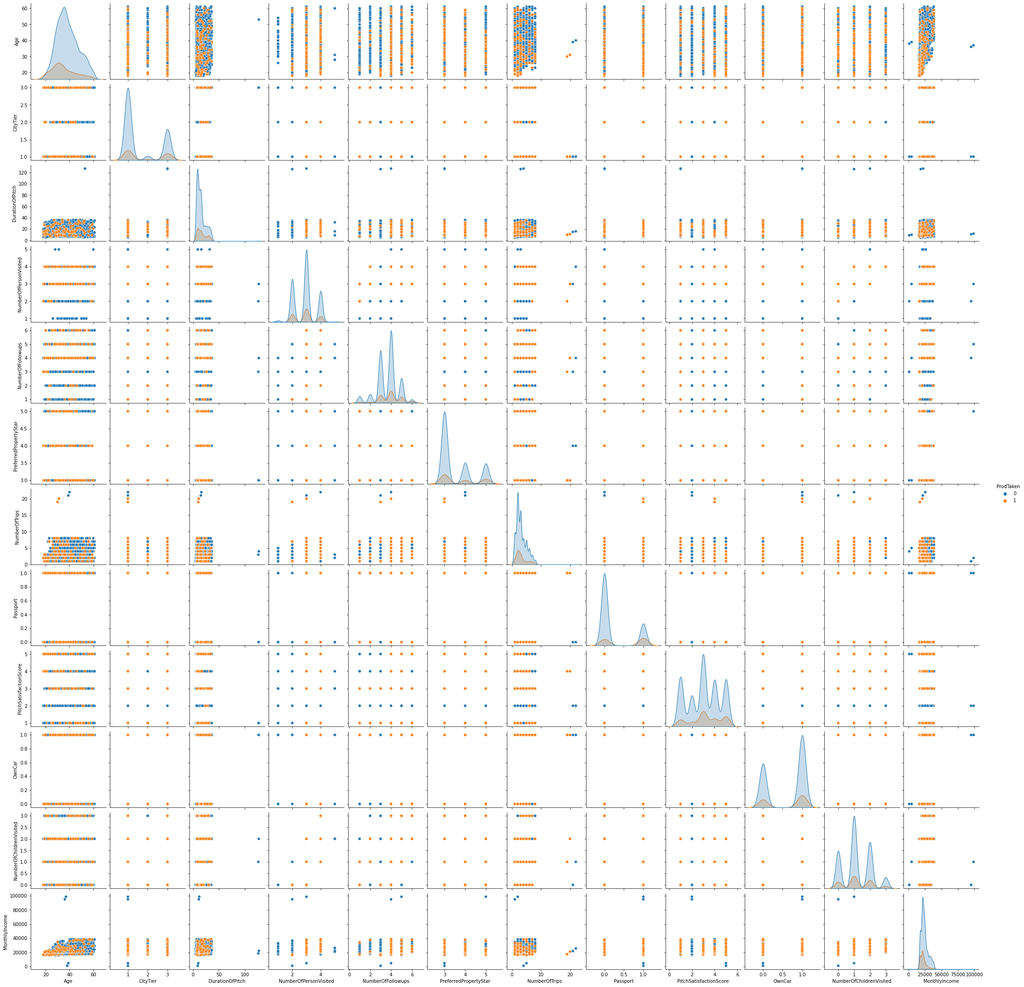

```python
sns.pairplot(data=data,hue="ProdTaken");
```

```python
data.groupby('ProdTaken').mean()
```

| ProdTaken | Age | CityTier | DurationOfPitch | NumberOfPersonVisited | NumberOfFollowups | PreferredPropertyStar | NumberOfTrips | Passport | PitchSatisfactionScore | OwnCar | NumberOfChildrenVisited | MonthlyIncome |
| --- | --- | --- | --- | --- | --- | --- | --- | --- | --- | --- | --- | --- |
| 0 | 38.282092 | 1.615927 | 15.169325 | 2.901714 | 3.654286 | 3.542806 | 3.219531 | 0.233871 | 3.044355 | 0.622984 | 1.184190 | 23960.962835 |
| 1 | 34.770548 | 1.819565 | 16.873143 | 2.919565 | 3.941886 | 3.746171 | 3.308370 | 0.536957 | 3.223913 | 0.608696 | 1.200438 | 22172.827703 |

#### Impact of age, duration of picth and income on purchase

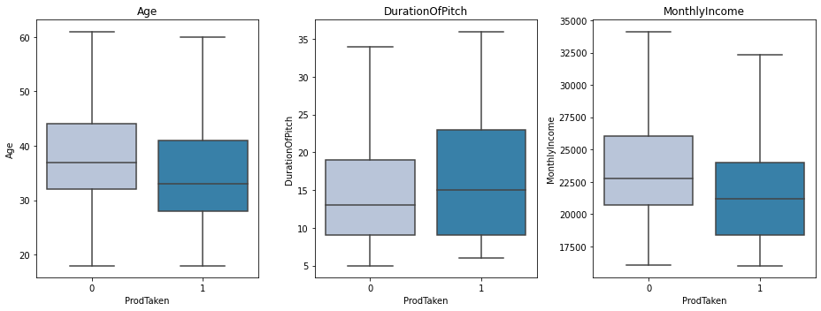

```python
cols = ['Age', 'DurationOfPitch', 'MonthlyIncome']
plt.figure(figsize=(13,5))

for i, variable in enumerate(cols):
                     plt.subplot(1,3,i+1)
                     sns.boxplot(x='ProdTaken', y=variable, data=data, palette="PuBu", showfliers=False)
                     plt.tight_layout()
                     plt.title(variable)
plt.show()
```

- People who purchased the product were younger than those who declined the product
- The duration of pitch was longer for those who purchased the product.
- The monthly income of those who purchased the product was lower which may seem contradictory.

#### Impact of City tier on purchase

```python
def stacked_plot(x):
    tab1 = pd.crosstab(x,data['ProdTaken'],margins=True)
    print(tab1)
    print('-'*120)
    tab = pd.crosstab(x,data['ProdTaken'],normalize='index')
    tab.plot(kind='bar',stacked=True,figsize=(10,5))
    plt.legend(loc='lower left', frameon=False)
    plt.legend(loc="upper left", bbox_to_anchor=(1,1))
    plt.show()
```

```
ProdTaken     0    1   All
CityTier
1          2670  520  3190
2           152   46   198
3          1146  354  1500
All        3968  920  4888
------------------------------------------------------------------------------------------------------------------------
```

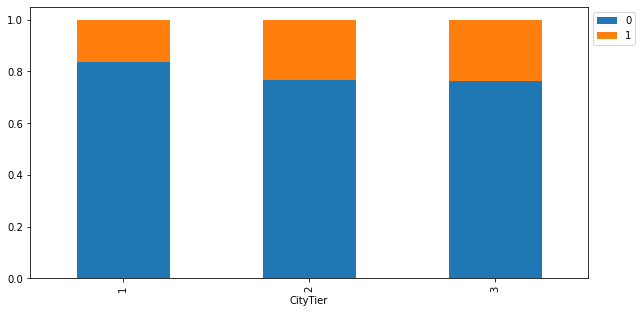

```python
stacked_plot(data['CityTier'])
```

- The higher the city tier, the higher is the proportion of customers pruchasing the product.

#### Impact of Gender on purchase

```
ProdTaken     0    1   All
Gender
Female     1630  342  1972
Male       2338  578  2916
All        3968  920  4888
------------------------------------------------------------------------------------------------------------------------
```

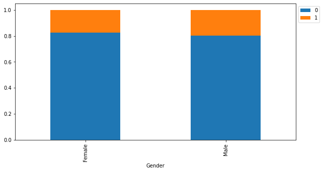

```python
stacked_plot(data['Gender'])
```

- No significant difference between male and female.

#### Impact of number of person visited on purchase

```
ProdTaken                 0    1   All
NumberOfPersonVisited
1                        39    0    39
2                      1151  267  1418
3                      1942  460  2402
4                       833  193  1026
5                         3    0     3
All                    3968  920  4888
------------------------------------------------------------------------------------------------------------------------
```

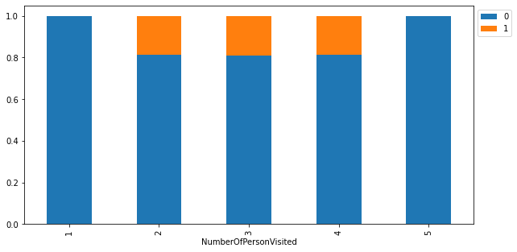

```python
stacked_plot(data['NumberOfPersonVisited'])
```

- There are not enough cases of number of person visited being 1 or 5 to draw any firm conclusions.
- We do not see any significant difference on the proportion of purchase when the number of person visited is 2, 3 or 4.

#### Impact of number of follow ups on purchase

[output not shown]

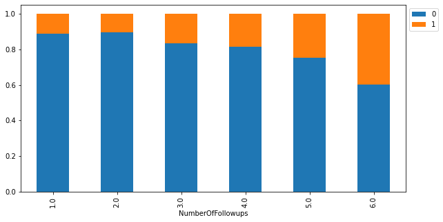

```python
stacked_plot(data['NumberOfFollowups'])
```

- The higher the number of follow ups the higher the proportion of customers purchasing the product.

#### Impact of preferred property rating on purchase

[output not shown]

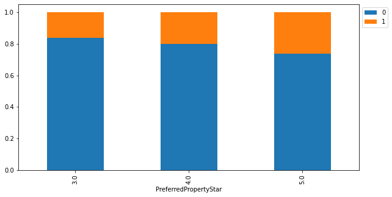

```python
stacked_plot(data['PreferredPropertyStar'])
```

- The higher the preferred property rating, the higher is the proportion of customers purchasing the product.

#### Impact of number of trips on purchase

[output not shown]

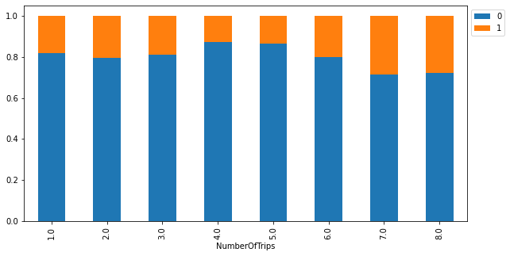

```python
stacked_plot(data[data['NumberOfTrips'] < 9]['NumberOfTrips'])
```

- The trend is not perfectly clear but it seems that the more trips, the higher is the proportion of customers purchasing the product.

#### Impact of passport on purchase

```
ProdTaken     0    1   All
Passport
0          3040  426  3466
1           928  494  1422
All        3968  920  4888
------------------------------------------------------------------------------------------------------------------------
```

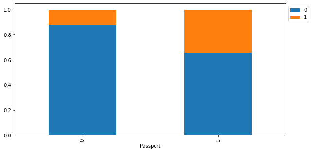

```python
stacked_plot(data['Passport'])
```

- The proportion of customers purchasing the product is greater among the people having a passport: 34.7% vs 12.3%